# Genotype likelihoods and reference quality calculations for QTip

Gregg Thomas

## I. Genotype likelihoods and quality scores

| 01 | 02 | 03 | 04 | 05 | 06 | 07 | 08 | 09 | 10 |
| --- | --- | --- | --- | --- | --- | --- | --- | --- | --- |
| AA | AT | AC | AG | TT | TC | TG | CC | CG | GG |

Given a genomic position and a set of reads mapped to that position (the data $D$), we want to calculate the probabiliy of each genotype ($P(G|D)$). GATK’s documentation gives the following method using Bayes theorem (https://software.broadinstitute.org/gatk/documentation/article.php?id=4442).

**Equation 1**

They state that the denominator can be ignored, because it is the same for all genotypes and that the prior probability of the genotypes is flat so I think it can also be ignored. Therefore, ignoring those two things we get:

**Equation 2**

$$P(G|D) = P(D|G)$$

or, the probability of a genotype given the data is equal to the likelihood of the data given the genotype. Then we must know how to calculate this likelihood.

Each genotype can be broken down into its two alleles:

**Equation 3**

$$G = \{A_1,A_2\}$$

For example, if $G = CG$, then $A_1 = C$ and $A_2 = G$.

**Equation 4**

$$P(D|G = \{A_1,A_2\}) = \prod_{r}^{R} (\frac{1}{2}P(b_r|A_1) + \frac{1}{2}P(b_r|A_2) )$$

The next question is then how do we calculate the probability of a base given an allele, $P(b|A)$?

GATK seems to use some table of marginalize likelihoods over all haplotypes (https://software.broadinstitute.org/gatk/documentation/article?id=4441), but I can’t find any useful information on that.

An easy approach to me seems to be to use the Phred base quality scores ($Q_s$) that are just scaled probabilities of sequencing error ($e_s$) (See: http://www.popgen.dk/angsd/index.php/Genotype_Likelihoods).

**Equation 5**

$$e_s = 10^{-\frac{Q_s}{10}}$$

Then, if the base at the current read $b$ matches the allele in the genotype $A$, we take 1 minus the probability that this is an error $e_s$, giving us the probability that it is not an error.

If the base at the current read $b$ does not match the allele in the genotype $A$, we assume that this is an error and divide the probability of error by 3, since there are 3 possible ways in which the read could be wrong (I need to understand this better).

In other words:

**Equation 6**

$$\begin{equation}
P(b|A) =
\begin{cases}
\frac{e_s}{3} & \text{: $b \neq A$}\\
1 - e_s & \text{: $b = A$}\\
\end{cases}
\end{equation}$$

Once genotype likelihoods for all 10 genotypes are calculated, the most likely (lowest scoring) genotype is chosen and a likelihood score ($L$) is calculated as the difference between the second lowest score ($min_2$) and the lowest score ($min$). (https://gatkforums.broadinstitute.org/gatk/discussion/4860/qual-vs-gq#latest, https://software.broadinstitute.org/gatk/documentation/article.php?id=1268)

**Equation 7**

$$L = min_2(P(D|G)) - min(P(D|G))$$

This likelihood is then re-scaled as a Phred score for the genotype ($Q_G$):

**Equation 8**

$$Q_G = -10 \log_{10}(L)$$

## II. Incorporating mapping quality

When calculating $P(b|A)$, we must also incorporate the Phred scaled mapping quality score $Q_m$ to find the probability that this position has been erroneously mapped ($e_m$). Then, since this and the sequencing probability error ($e_s$) are independendt probabilities (ARE THEY?), to get the total probability of error at that position, we simply take their product to calculate $P(b|A)$:

**Equation 9**

$$\begin{equation}
P(b|A) =
\begin{cases}
\frac{(e_s * e_m)}{3} & \text{: $b \neq A$}\\
1 - (e_s * e_m) & \text{: $b = A$}\\
\end{cases}
\end{equation}$$

## III. Example read sets with and without mapping quality

I want to see the behavior of this calculation when we have decent coverage (20 reads?) and one read has an alternate allele. How does changing the base quality score of the alternate allele affect genotype calls and quality scores?

**Read set 1 (Depth = 20) – no mapping quality**

| Read | A | A | A | A | A | A | A | A | A | A | A | A | A | A | A | A | A | A | A | T |
| --- | --- | --- | --- | --- | --- | --- | --- | --- | --- | --- | --- | --- | --- | --- | --- | --- | --- | --- | --- | --- |
| $Q_s$ | 40 | 40 | 40 | 40 | 40 | 40 | 40 | 40 | 40 | 40 | 40 | 40 | 40 | 40 | 40 | 40 | 40 | 40 | 40 | 1-40 |

**Read set 2 (Depth = 20) – with mapping quality**

| Read | A | A | A | A | A | A | A | A | A | A | A | A | A | A | A | A | A | A | A | T |
| --- | --- | --- | --- | --- | --- | --- | --- | --- | --- | --- | --- | --- | --- | --- | --- | --- | --- | --- | --- | --- |
| $Q_s$ | 40 | 40 | 40 | 40 | 40 | 40 | 40 | 40 | 40 | 40 | 40 | 40 | 40 | 40 | 40 | 40 | 40 | 40 | 40 | 40 |
| $Q_m$ | 40 | 40 | 40 | 40 | 40 | 40 | 40 | 40 | 40 | 40 | 40 | 40 | 40 | 40 | 40 | 40 | 40 | 40 | 40 | 1-40 |

**Figure 1 – Calculating the Genotype quality score given a set of reads with one alternat allele that varies in base quality (left) or mapping quality (right). The left panel does not incorporate mapping quality information at all.**

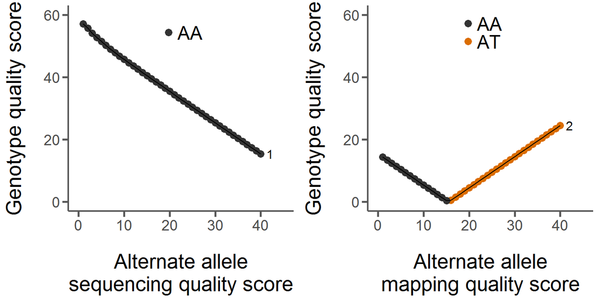

### What happens if we change the number of reads?

**Read set 3 (Depth = 10) – no mapping quality**

| Read | A | A | A | A | A | A | A | A | A | T |  |
| --- | --- | --- | --- | --- | --- | --- | --- | --- | --- | --- | --- |
| $Q_s$ | 40 | 40 | 40 | 40 | 40 | 40 | 40 | 40 | 40 | 1-40 |  |

**Read set 4 (Depth = 15) – no mapping quality**

| Read | A | A | A | A | A | A | A | A | A | A | A | A | A | A | T |  |
| --- | --- | --- | --- | --- | --- | --- | --- | --- | --- | --- | --- | --- | --- | --- | --- | --- |
| $Q_s$ | 40 | 40 | 40 | 40 | 40 | 40 | 40 | 40 | 40 | 40 | 40 | 40 | 40 | 40 | 1-40 |  |

**Read set 5 (Depth = 25) – no mapping quality**

| Read | A | A | A | A | A | A | A | A | A | A | A | A | A | A | A | A | A | A | A | A |
| --- | --- | --- | --- | --- | --- | --- | --- | --- | --- | --- | --- | --- | --- | --- | --- | --- | --- | --- | --- | --- |
| $Q_s$ | 40 | 40 | 40 | 40 | 40 | 40 | 40 | 40 | 40 | 40 | 40 | 40 | 40 | 40 | 40 | 40 | 40 | 40 | 40 | 40 |

**Read set 6 (Depth = 10) – with mapping quality**

| Read | A | A | A | A | A | A | A | A | A | T |  |
| --- | --- | --- | --- | --- | --- | --- | --- | --- | --- | --- | --- |
| $Q_s$ | 40 | 40 | 40 | 40 | 40 | 40 | 40 | 40 | 40 | 40 |  |
| $Q_m$ | 40 | 40 | 40 | 40 | 40 | 40 | 40 | 40 | 40 | 1-40 |  |

**Read set 7 (Depth = 15) – with mapping quality**

| Read | A | A | A | A | A | A | A | A | A | A | A | A | A | A | T |  |
| --- | --- | --- | --- | --- | --- | --- | --- | --- | --- | --- | --- | --- | --- | --- | --- | --- |
| $Q_s$ | 40 | 40 | 40 | 40 | 40 | 40 | 40 | 40 | 40 | 40 | 40 | 40 | 40 | 40 | 40 |  |
| $Q_m$ | 40 | 40 | 40 | 40 | 40 | 40 | 40 | 40 | 40 | 40 | 40 | 40 | 40 | 40 | 1-40 |  |

**Read set 8 (Depth = 25) – with mapping quality**

| Read | A | A | A | A | A | A | A | A | A | A | A | A | A | A | A | A | A | A | A | A |
| --- | --- | --- | --- | --- | --- | --- | --- | --- | --- | --- | --- | --- | --- | --- | --- | --- | --- | --- | --- | --- |
| $Q_s$ | 40 | 40 | 40 | 40 | 40 | 40 | 40 | 40 | 40 | 40 | 40 | 40 | 40 | 40 | 40 | 40 | 40 | 40 | 40 | 40 |
| $Q_m$ | 40 | 40 | 40 | 40 | 40 | 40 | 40 | 40 | 40 | 40 | 40 | 40 | 40 | 40 | 40 | 40 | 40 | 40 | 40 | 40 |

**Figure 2 – Calculating the Genotype quality score given a set of reads with one alternate allele that varies in base quality (left) or mapping quality (right) while also varying the read depth. The left panel does not incorporate mapping quality information at all. Reads sets 3 and 6 have depth = 10, read sets 4 and 7 have depth = 15, read sets 1 and 2 have depth = 20, and read sets 5 and 8 have depth = 25**

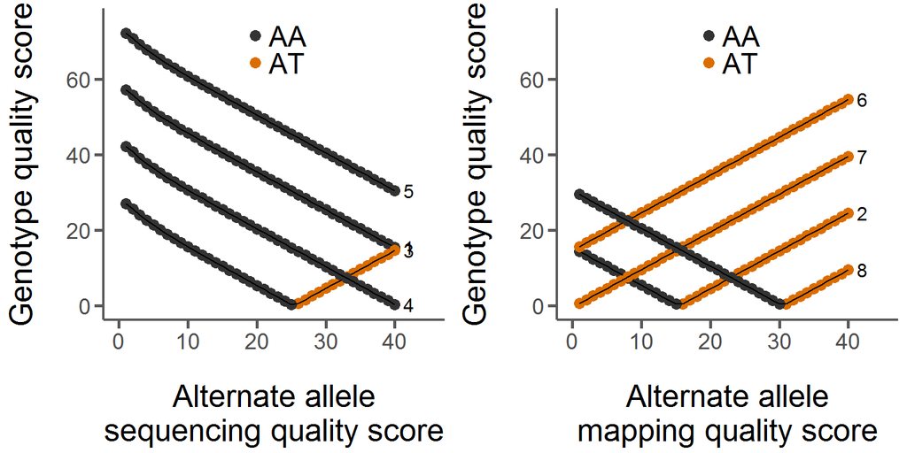

### What happens if we change the number of alternate alleles?

**Read set 9 (Depth = 20) – no mapping quality**

| Read | A | A | A | A | A | A | A | A | A | A | A | A | A | A | A | A | A | A | T | T |
| --- | --- | --- | --- | --- | --- | --- | --- | --- | --- | --- | --- | --- | --- | --- | --- | --- | --- | --- | --- | --- |
| $Q_s$ | 40 | 40 | 40 | 40 | 40 | 40 | 40 | 40 | 40 | 40 | 40 | 40 | 40 | 40 | 40 | 40 | 40 | 40 | 40 | 1-40 |

**Read set 10 (Depth = 20) – no mapping quality**

| Read | A | A | A | A | A | A | A | A | A | A | A | A | A | A | A | A | A | T | T | T |
| --- | --- | --- | --- | --- | --- | --- | --- | --- | --- | --- | --- | --- | --- | --- | --- | --- | --- | --- | --- | --- |
| $Q_s$ | 40 | 40 | 40 | 40 | 40 | 40 | 40 | 40 | 40 | 40 | 40 | 40 | 40 | 40 | 40 | 40 | 40 | 40 | 40 | 1-40 |

**Read set 11 (Depth = 20) – no mapping quality**

| Read | A | A | A | A | A | A | A | A | A | A | A | A | A | A | A | A | T | T | T | T |
| --- | --- | --- | --- | --- | --- | --- | --- | --- | --- | --- | --- | --- | --- | --- | --- | --- | --- | --- | --- | --- |
| $Q_s$ | 40 | 40 | 40 | 40 | 40 | 40 | 40 | 40 | 40 | 40 | 40 | 40 | 40 | 40 | 40 | 40 | 40 | 40 | 40 | 1-40 |

**Read set 12 (Depth = 20) – with mapping quality**

| Read | A | A | A | A | A | A | A | A | A | A | A | A | A | A | A | A | A | A | T | T |
| --- | --- | --- | --- | --- | --- | --- | --- | --- | --- | --- | --- | --- | --- | --- | --- | --- | --- | --- | --- | --- |
| $Q_s$ | 40 | 40 | 40 | 40 | 40 | 40 | 40 | 40 | 40 | 40 | 40 | 40 | 40 | 40 | 40 | 40 | 40 | 40 | 40 | 40 |
| $Q_m$ | 40 | 40 | 40 | 40 | 40 | 40 | 40 | 40 | 40 | 40 | 40 | 40 | 40 | 40 | 40 | 40 | 40 | 40 | 40 | 1-40 |

**Read set 13 (Depth = 20) – with mapping quality**

| Read | A | A | A | A | A | A | A | A | A | A | A | A | A | A | A | A | A | T | T | T |
| --- | --- | --- | --- | --- | --- | --- | --- | --- | --- | --- | --- | --- | --- | --- | --- | --- | --- | --- | --- | --- |
| $Q_s$ | 40 | 40 | 40 | 40 | 40 | 40 | 40 | 40 | 40 | 40 | 40 | 40 | 40 | 40 | 40 | 40 | 40 | 40 | 40 | 40 |
| $Q_m$ | 40 | 40 | 40 | 40 | 40 | 40 | 40 | 40 | 40 | 40 | 40 | 40 | 40 | 40 | 40 | 40 | 40 | 40 | 40 | 1-40 |

**Read set 14 (Depth = 20) – with mapping quality**

| Read | A | A | A | A | A | A | A | A | A | A | A | A | A | A | A | A | T | T | T | T |
| --- | --- | --- | --- | --- | --- | --- | --- | --- | --- | --- | --- | --- | --- | --- | --- | --- | --- | --- | --- | --- |
| $Q_s$ | 40 | 40 | 40 | 40 | 40 | 40 | 40 | 40 | 40 | 40 | 40 | 40 | 40 | 40 | 40 | 40 | 40 | 40 | 40 | 40 |
| $Q_m$ | 40 | 40 | 40 | 40 | 40 | 40 | 40 | 40 | 40 | 40 | 40 | 40 | 40 | 40 | 40 | 40 | 40 | 40 | 40 | 1-40 |

**Figure 3 – Calculating the Genotype quality score given a set of reads with one alternate allele that varies in base quality (left) or mapping quality (right) while also adding more high quality alternate alleles. The left panel does not incorporate mapping quality information at all. Reads sets 1 and 2 have 1 alternate allele, read sets 9 and 12 have 2 alternat alleles, read sets 10 and 13 have 3 alternate alelles, and read sets 11 and 14 have 4 alternate alelles**

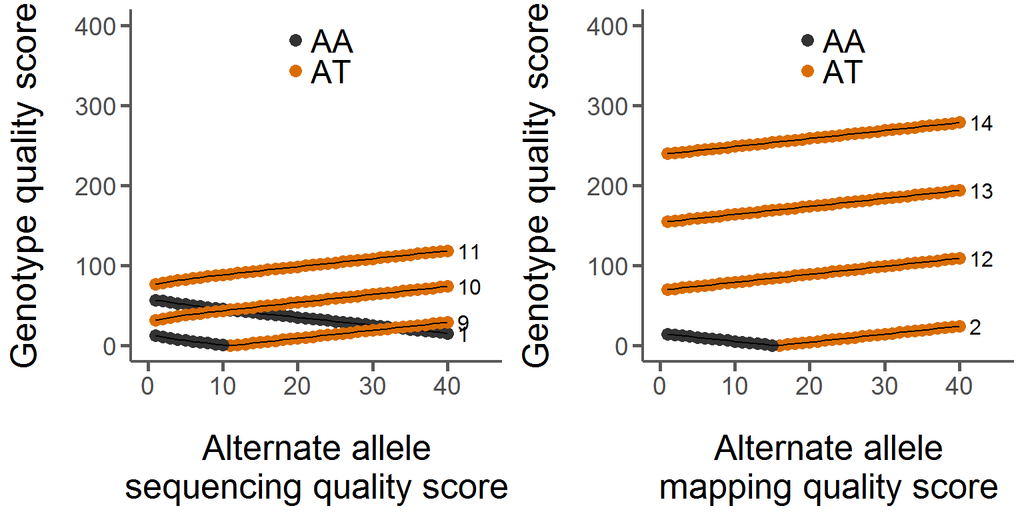

### What happens if we vary both base and mapping quality simultaneously?

**Read set 15 (Depth = 20) – with mapping quality**

| Read | A | A | A | A | A | A | A | A | A | A | A | A | A | A | A | A | A | A | A | T |
| --- | --- | --- | --- | --- | --- | --- | --- | --- | --- | --- | --- | --- | --- | --- | --- | --- | --- | --- | --- | --- |
| $Q_s$ | 40 | 40 | 40 | 40 | 40 | 40 | 40 | 40 | 40 | 40 | 40 | 40 | 40 | 40 | 40 | 40 | 40 | 40 | 40 | 1-40 |
| $Q_m$ | 40 | 40 | 40 | 40 | 40 | 40 | 40 | 40 | 40 | 40 | 40 | 40 | 40 | 40 | 40 | 40 | 40 | 40 | 40 | 1-40 |

**Figure 4 – The most likely genotype given a set of reads with one alternate allele that varies in base quality AND mapping quality.**

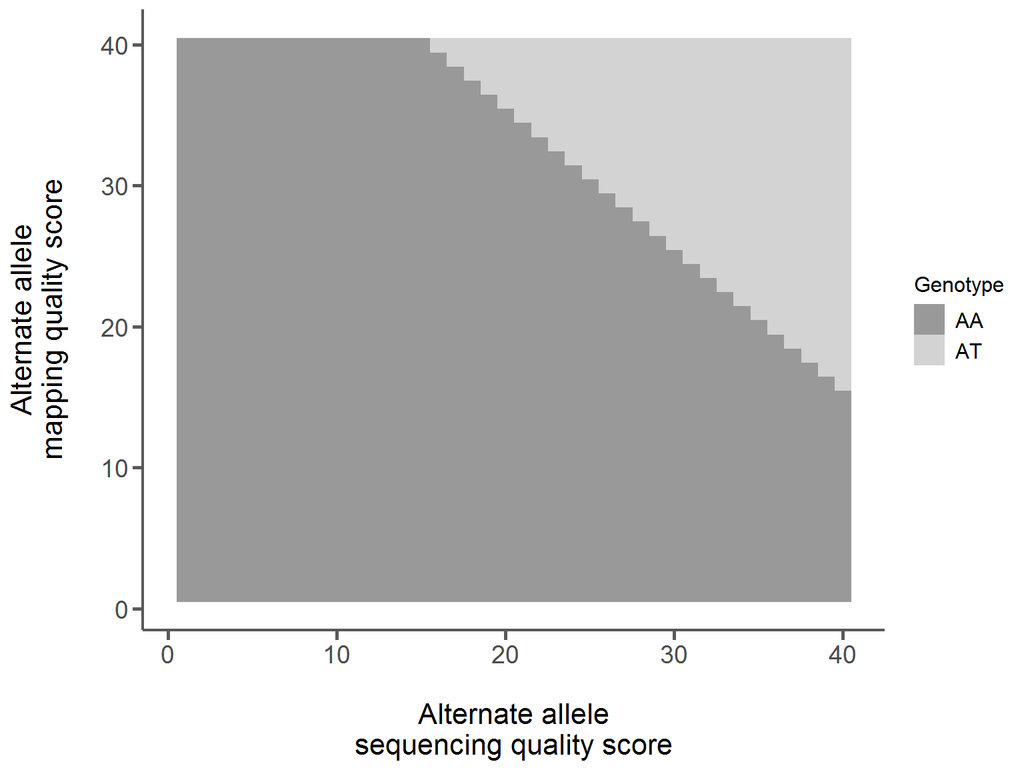

## IV. A reference base quality score

Incorporating mapping quality allows us to assign quality scores ($Q_R$) to every position in an assembled genome by mapping the reads back to the assembly. To do this, we sum the likelihoods of all genotypes that contain the called base and those that don’t and then take the difference.

First, we sum all the likelihoods of genotypes that contain the reference allele $A_R$:

**Equation 10**

$$L_1 = \sum_{g}^{G} P(D|G = \{A_1, A_2\}) | A_R \in G$$

Next we get the sum of all the likelihoods that do not contain the reference allele:

**Equation 11**

$$L_2 = \sum_{g}^{G} P(D|G = \{A_1, A_2\}) | A_R \notin G$$

Then our reference quality score $Q_R$ is simply the difference of these two likelihood sums:

**Equation 12**

$$Q_R = |L_2 - L_1|$$

### Reference quality score varying sequencing and mapping quality score independently

**Figure 5 – Calculating the Reference quality score given a set of reads with one alternate allele that varies in base quality (left) or mapping quality (right). The left panel does not incorporate mapping quality information at all.**

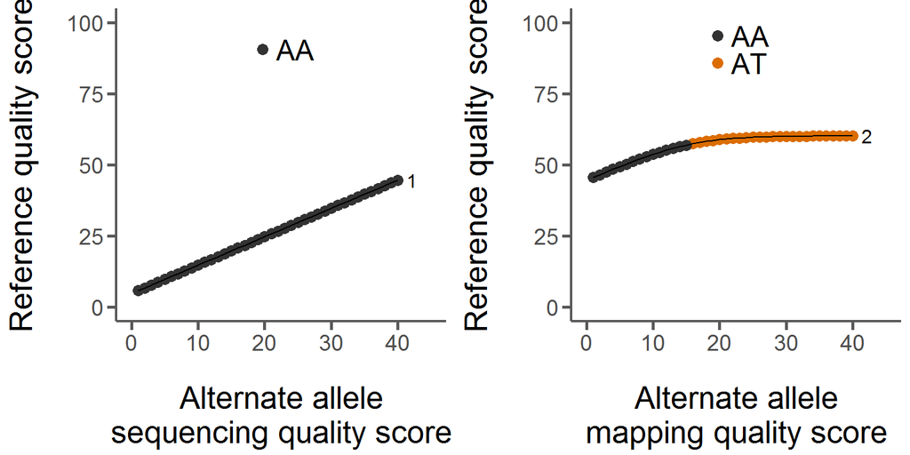

### Reference quality score varying both sequencing and mapping quality score simultaneously

**Figure 6 – Calculating the Reference quality score given a set of reads with one alternate allele that varies in base quality AND mapping quality. Reference quality scores are dotted contours with labels.**

[figure not shown]